# XRP-USD

## XRP-USD today is +0200, 2025-10-26, 19:33:44

This crypto forecast was generated by gemini-2.0-flash API

## Daily Chart

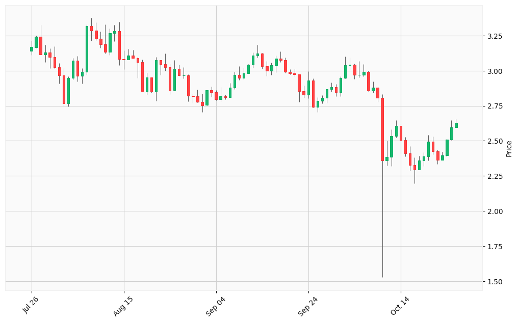

## Hourly Chart

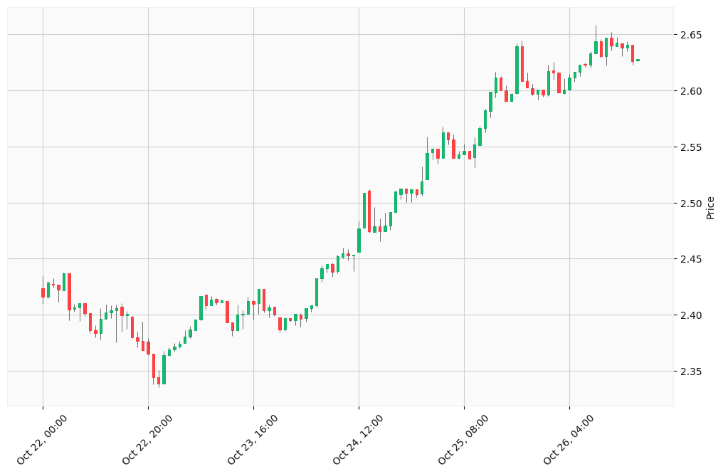

Okay, I will analyze the provided XRP-USD charts (daily for the last three months and hourly for the last five days) and generate buy/sell signals based on the steps you’ve outlined. I will use technical analysis on the provided data. Since I don’t have direct access to real-time market data, financial news, or economic indicators via live APIs, I will base my analysis and signals *solely* on the provided OHLCV data and the technical indicators you specified. The “News and Economic Analysis” step will therefore be limited. Confidence levels will inherently be lower due to this limitation.

Here’s how I’ll proceed:

1. **Data Preparation:** I will load the provided data.
2. **Technical Indicator Calculation:** I will calculate the technical indicators you mentioned (Moving Averages, RSI, MACD, Bollinger Bands). Due to the limited nature of the data, I may need to adjust the periods used for these indicators.
3. **Trend Analysis:** I will identify trends based on the price action and moving averages.
4. **Signal Generation:** I will generate buy/sell signals based on the indicators and trend analysis.
5. **Output Formatting:** I will present the signals in the format you specified.

**Disclaimer:** *These signals are for informational purposes only and should not be considered financial advice. Trading cryptocurrencies involves substantial risk of loss. The analysis below is based solely on the provided data and lacks real-time market context.*